# COMPSCIX 415.2 Homework 5/Midterm

Gwen Rino

2/28/2018

```r
library(tidyverse)
```

## GITHUB LINK

[https://github.com/gwenrino/compscix-415-2-assignments]

## THE TIDYVERSE

Name the package and two functions associated with each task

| Task | Package | Function1 | Function2 |
| --- | --- | --- | --- |
| Plotting | ggplot | geom_point | geom_smooth |
| Munging/wrangling | dplyr | filter | summarize |
| Reshaping | tidyr | gather | spread |
| Importing/exporting | readr | read_delim | read_csv |

## R BASICS

1. Code fixed with only one change

```r
My_data.name___is.too00ooLong <- c( 1 , 2   , 3 )
```

2. Code fixed

```r
my_string <- c('had', 'two', 'errors', 'in', 'it', 'but', 'works', 'now')
```

3. As coded, three of the elements of `my_vector` are integers and two are characters. But vectors can only contain one type of element, so R converted the integers to characters.

## DATA IMPORT/EXPORT

Demonstration of import/export:

```r
rail_trail <- read_delim("rail_trail.txt", delim = "|") # Load rail_trail.txt
glimpse(rail_trail)
```

```
## Observations: 90
## Variables: 10
## $ hightemp   <int> 83, 73, 74, 95, 44, 69, 66, 66, 80, 79, 78, 65, 41,...
## $ lowtemp    <int> 50, 49, 52, 61, 52, 54, 39, 38, 55, 45, 55, 48, 49,...
## $ avgtemp    <dbl> 66.5, 61.0, 63.0, 78.0, 48.0, 61.5, 52.5, 52.0, 67....
## $ spring     <int> 0, 0, 1, 0, 1, 1, 1, 1, 0, 0, 0, 1, 1, 0, 0, 1, 0, ...
## $ summer     <int> 1, 1, 0, 1, 0, 0, 0, 0, 1, 1, 1, 0, 0, 0, 0, 0, 1, ...
## $ fall       <int> 0, 0, 0, 0, 0, 0, 0, 0, 0, 0, 0, 0, 0, 1, 1, 0, 0, ...
## $ cloudcover <dbl> 7.6, 6.3, 7.5, 2.6, 10.0, 6.6, 2.4, 0.0, 3.8, 4.1, ...
## $ precip     <dbl> 0.00, 0.29, 0.32, 0.00, 0.14, 0.02, 0.00, 0.00, 0.0...
## $ volume     <int> 501, 419, 397, 385, 200, 375, 417, 629, 533, 547, 4...
## $ weekday    <int> 1, 1, 1, 0, 1, 1, 1, 0, 0, 1, 1, 1, 1, 1, 1, 1, 0, ...
```

```r
saveRDS(rail_trail, file = "rail_trail.rds") # Export rail_trail as rds file

rail_trail_rds <- readRDS(file = "rail_trail.rds") # Reload rail_trail.rds
glimpse(rail_trail_rds)
```

```
## Observations: 90
## Variables: 10
## $ hightemp   <int> 83, 73, 74, 95, 44, 69, 66, 66, 80, 79, 78, 65, 41,...
## $ lowtemp    <int> 50, 49, 52, 61, 52, 54, 39, 38, 55, 45, 55, 48, 49,...
## $ avgtemp    <dbl> 66.5, 61.0, 63.0, 78.0, 48.0, 61.5, 52.5, 52.0, 67....
## $ spring     <int> 0, 0, 1, 0, 1, 1, 1, 1, 0, 0, 0, 1, 1, 0, 0, 1, 0, ...
## $ summer     <int> 1, 1, 0, 1, 0, 0, 0, 0, 1, 1, 1, 0, 0, 0, 0, 0, 1, ...
## $ fall       <int> 0, 0, 0, 0, 0, 0, 0, 0, 0, 0, 0, 0, 0, 1, 1, 0, 0, ...
## $ cloudcover <dbl> 7.6, 6.3, 7.5, 2.6, 10.0, 6.6, 2.4, 0.0, 3.8, 4.1, ...
## $ precip     <dbl> 0.00, 0.29, 0.32, 0.00, 0.14, 0.02, 0.00, 0.00, 0.0...
## $ volume     <int> 501, 419, 397, 385, 200, 375, 417, 629, 533, 547, 4...
## $ weekday    <int> 1, 1, 1, 0, 1, 1, 1, 0, 0, 1, 1, 1, 1, 1, 1, 1, 0, ...
```

## VISUALIZATION

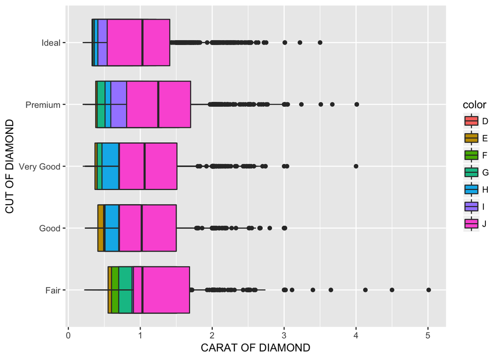

```r
ggplot(diamonds, aes(x=cut, y=carat)) +
  geom_boxplot(aes(fill=color), position = "identity") +
  xlab("CUT OF DIAMOND") +
  ylab("CARAT OF DIAMOND") +
  coord_flip()
```

3. It is much easier to visualize and compare the distributions of the carat variable for each combination of diamond cut and color if the graph uses the “dodge” position instead of “identity.”

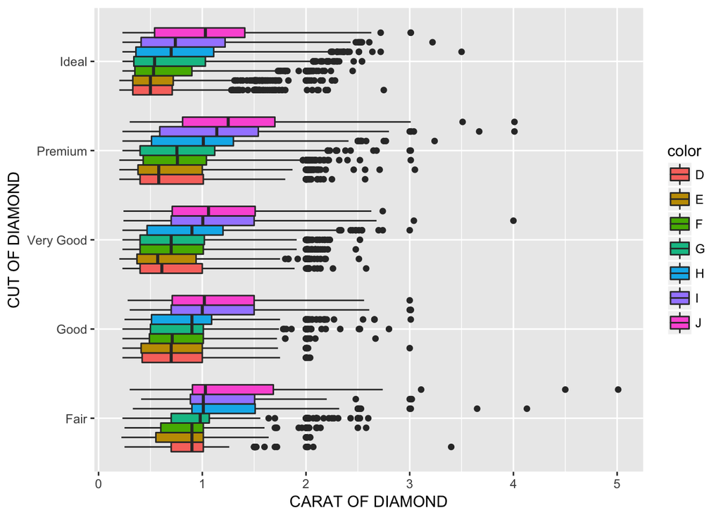

```r
ggplot(diamonds, aes(x=cut, y=carat)) +
  geom_boxplot(aes(fill=color), position = "dodge") +
  xlab("CUT OF DIAMOND") +
  ylab("CARAT OF DIAMOND") +
  coord_flip()
```

## DATA MUNGING AND WRANGLING

1. The data in the column “type” needs to be spread, as shown here:

```r
spread(table2, key = type, value = count)
```

```
## # A tibble: 6 x 4
##   country      year  cases population
## * <chr>       <int>  <int>      <int>
## 1 Afghanistan  1999    745   19987071
## 2 Afghanistan  2000   2666   20595360
## 3 Brazil       1999  37737  172006362
## 4 Brazil       2000  80488  174504898
## 5 China        1999 212258 1272915272
## 6 China        2000 213766 1280428583
```

2. Here is the code that adds a new column to the diamonds data set called `price_per_carat` that shows the price of each diamond per carat.

```r
diamonds %>% mutate(price_per_carat = price/carat)
```

3. The output below shows how many diamonds of each cut there are total, and also how many and what proportion of these have a price > 10,000 and a carat < 1.5.

The results make sense. Only a tiny proportion of the diamonds in the dataset are both relatively small (<1.5 carats) and also relatively expensive (>$10,000). However, a higher proportion of the better cut diamonds fall into this category than the poorer cut diamonds.

The number of diamonds that meet the >$10,000 & <1.5 carat requirements in each group may be misleading because the total number of diamonds in each group varies so much. But the proportion of diamonds that meet the requirements accounts for the differences in group size.

```r
diamonds %>% group_by(cut) %>%
  summarize(
    total_count = n(),
    group_count = sum(price > 10000 & carat < 1.5),
    group_proportion = mean(price > 10000 & carat < 1.5)
  )
```

```
## # A tibble: 5 x 4
##   cut       total_count group_count group_proportion
##   <ord>           <int>       <int>            <dbl>
## 1 Fair             1610           4          0.00248
## 2 Good             4906          17          0.00347
## 3 Very Good       12082         155          0.0128
## 4 Premium         13791         173          0.0125
## 5 Ideal           21551         485          0.0225
```

## EDA

1. This data is from the beginning of 2000 to halfway through 2015.

```r
range(txhousing$date)
```

```
## [1] 2000.0 2015.5
```

2. 46 cities are represented.

```r
nrow(distinct(txhousing, city))
```

```
## [1] 46
```

3. The highest number of sales, 8945, occurred in Houston in July 2015.

```r
txhousing %>% group_by(city, month, year) %>%
  arrange(desc(sales))
```

```
## # A tibble: 8,602 x 9
## # Groups:   city, month, year [8,602]
##    city     year month sales     volume median listings inventory  date
##    <chr>   <int> <int> <dbl>      <dbl>  <dbl>    <dbl>     <dbl> <dbl>
##  1 Houston  2015     7  8945 2568156780 217600    23875      3.40  2016
##  2 Houston  2006     6  8628 1795898108 155200    36281      5.60  2006
##  3 Houston  2013     7  8468 2168720825 187800    21497      3.30  2014
##  4 Houston  2015     6  8449 2490238594 222400    22311      3.20  2015
##  5 Houston  2013     5  8439 2121508529 186100    20526      3.30  2013
##  6 Houston  2014     6  8391 2342443127 211200    19725      2.90  2014
##  7 Houston  2014     7  8391 2278932511 199700    20214      3.00  2014
##  8 Houston  2014     8  8167 2195184825 202400    20007      2.90  2015
##  9 Houston  2013     8  8155 2083377894 186700    21366      3.30  2014
## 10 Houston  2006     5  8040 1602621368 151200    35398      5.50  2006
## # ... with 8,592 more rows
```

4. I expect that the more listings there are, the more sales there are. The visualization below affirms my assumption.

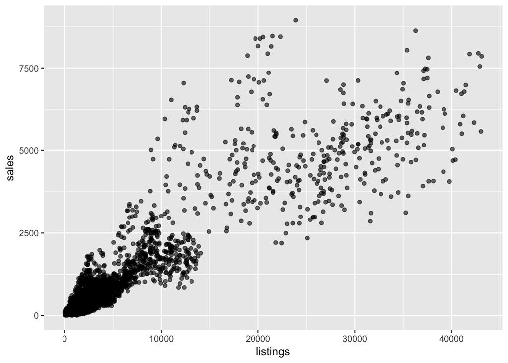

```r
ggplot(txhousing, aes(x=listings, y=sales)) +
  geom_point(alpha=.6)
```

5. See table below for the proportion of sales missing for each city.

```r
txhousing %>% group_by(city) %>%
  summarize(proportion = mean(is.na(sales)))
```

```
## # A tibble: 46 x 2
##    city                  proportion
##    <chr>                      <dbl>
##  1 Abilene                   0
##  2 Amarillo                  0
##  3 Arlington                 0
##  4 Austin                    0
##  5 Bay Area                  0
##  6 Beaumont                  0
##  7 Brazoria County           0.0749
##  8 Brownsville               0.0107
##  9 Bryan-College Station     0
## 10 Collin County             0
## # ... with 36 more rows
```

6. Looking at only the cities and months with greater than 500 sales:

```r
bigsales <- txhousing %>% rename(med_price = median) %>% filter(sales > 500)
```

1. The distributions of the median sales price when grouped by city differ quite a bit. See below.

```r
# This table shows that the city with the highest median price was Collin County ($196,000),
# and the city with the lowest median price was Ft. Worth ($114,600).
bigsales %>% group_by(city) %>%
  summarize(median_price = median(med_price)) %>%
  arrange(desc(median_price))
```

```
## # A tibble: 14 x 2
##    city              median_price
##    <chr>                    <dbl>
##  1 Collin County           196000
##  2 Austin                  179400
##  3 Montgomery County       178750
##  4 Fort Bend               177500
##  5 Denton County           163200
##  6 NE Tarrant County       160800
##  7 Bay Area                156250
##  8 Dallas                  154500
##  9 Houston                 148400
## 10 San Antonio             143300
## 11 El Paso                 131200
## 12 Arlington               129300
## 13 Corpus Christi          129300
## 14 Fort Worth              114600
```

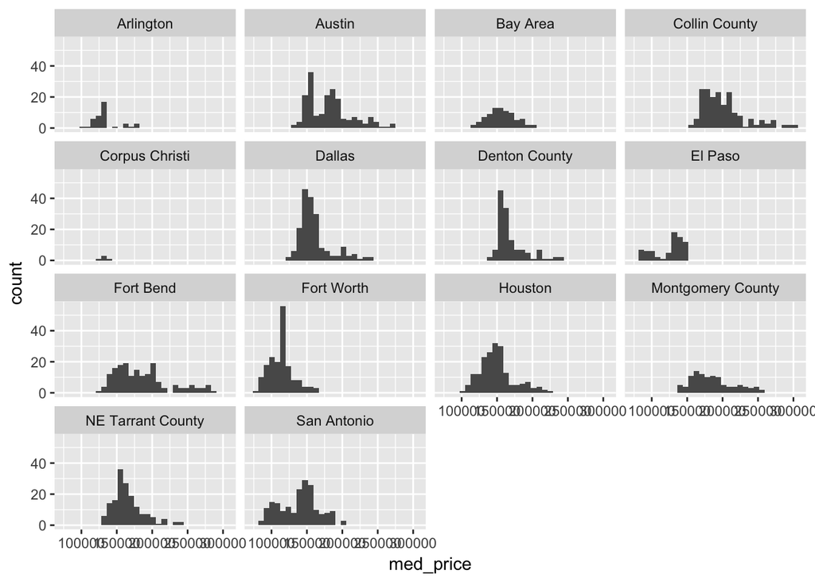

```r
# These histograms of the distribution of median prices by city vary a lot in shape.
# For example, Bay Area is unimodal and nearly symmetrical, Dallas is unimodal and skews right,
# and Austin is bimodal.
ggplot(bigsales, aes(x = med_price)) +
  geom_histogram() +
  facet_wrap(~ city)
```

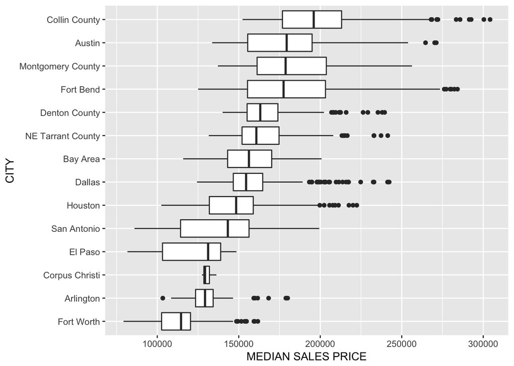

```r
# These boxplots are another visualization of the distribution of median sales prices for
# each city, and they also show a lot of variation. For example, the lower two quartiles of
# El Paso median prices cover a much wider spread than the upper two quartiles,
# while Denton County is the opposite.
ggplot(bigsales) +
  geom_boxplot(aes(x = reorder(city, med_price, FUN = median), y = med_price)) +
  xlab("CITY") +
  ylab("MEDIAN SALES PRICE") +
  coord_flip()
```

2. I would be curious to investigate Austin further to try to understand its bimodal distribution of median prices. Maybe housing prices shot up suddenly at some point, or crashed? I’d also like to understand why the cities with the highest median sales prices (Collin County, Austin, Montgomery County, Fort Bend) also seem to have the greatest range in their upper quartile median prices. This really contrasts with El Paso, a city with a low median and very little range in its upper quartile median prices.
3. The smaller the number of observations in a group, the less meaningful measures of center like median are. That might be a reason to filter out all cities and months with sales less than 500.